# Inequality: Prison and Jail in the United States

Ellen Huynh

2022-11-23

## Abstract

Data from the non-profit Vera Project describes incarceration data from 1970-2018. Through investigation of prison and jail population/admissions, inequalities and/or patterns are highlighted. This is further emphasized through the lens of race, time, and location. The conclusions points to the specific difference between black and white male prison admissions.

## Introduction

### Social Issue:

In Data Feminism we learn the power of data and subsequently data visualizations. The Vera project plans to reshape and remove the over criminalization and incarceration of minority groups. Individuals face social issues as they enter and exit incarceration regardless of racial identity, such effects are highlighted through racial disparity.

### Stakeholders:

There are multiple stakeholders in terms of the social and economical impacts of incarceration. With the data collected, the (most) direct stakeholder is of course incarcerated people. But others can also include people working at correctional facilities and lawyers. Indirect stakeholders can include the family and communities of incarcerated people, or city leaders/lawmakers.

### Questions:

Through this data I will be able to answer the question of:

- Does the total U.S. jail population increase or decrease overtime?
- How does the prison population over time vary between states?
- How does the difference between white males admitted into prison and black males admitted into prison highlight inequality?
- How is the difference between black and white males admitted into prison distribute geographically?
  - Are there any patterns in the distribution of such inequality pattern?

## Growth of U.S. Prison Population

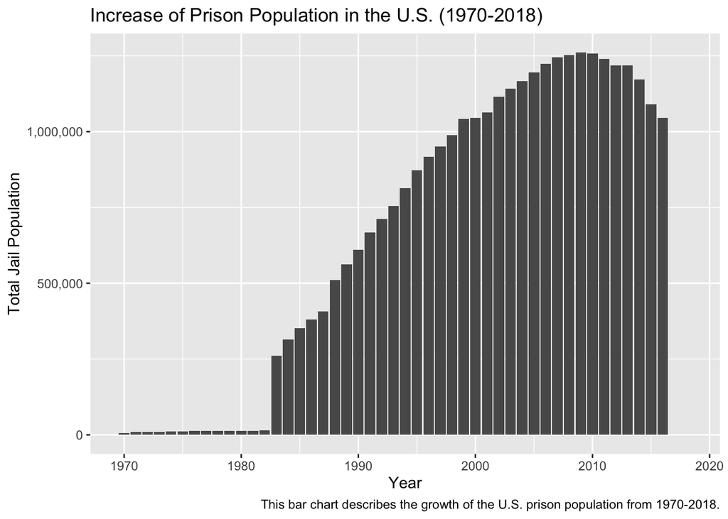

## Growth of Prison Population by State

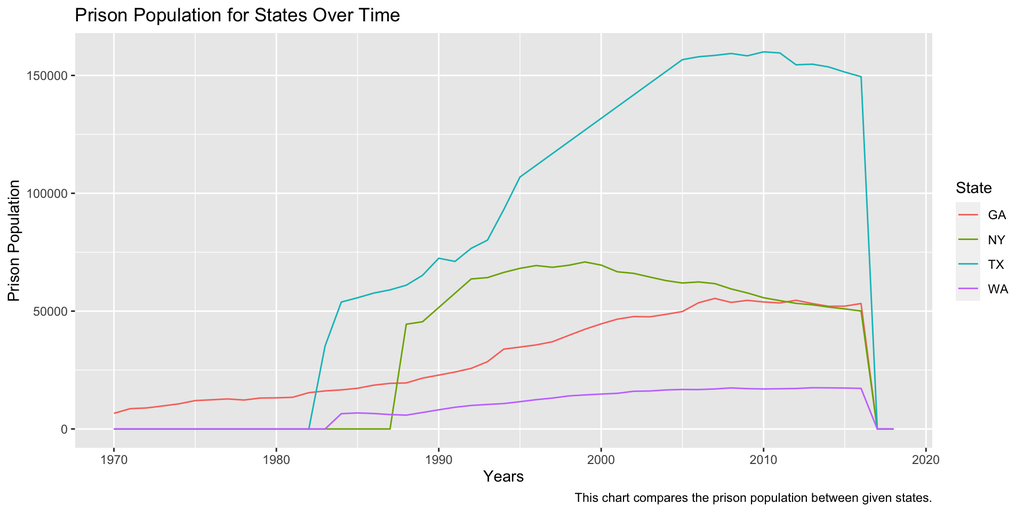

## Inequality Through Prison Admission Pattern

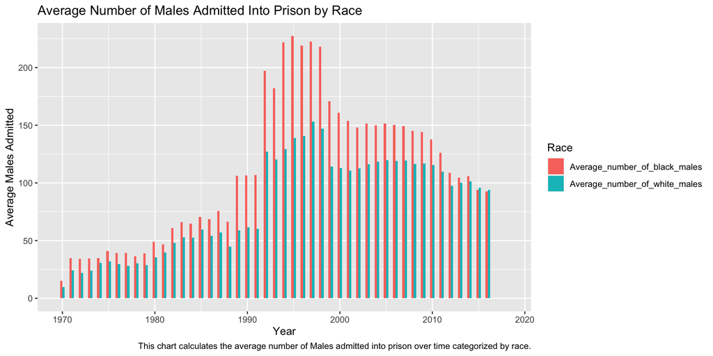

### Summary:

The following chart can be used to answer the question: *How does the difference between white males admitted into prison and black males admitted into prison highlight inequality?* To answer this question, there is inequality because it is clear that the number of black males admitted is consistently higher than the number of white males. To put it simply, the red lines (which represent the average number of black males admitted in a given year) are often higher than the blue ones (represent the average number of white males admitted in a given year). In particular, the year with the largest difference between Black and White males admitted was in **1994**. So far, there have only been two years where the average white value is higher than the average black value, that year having the smallest difference of **2015**. Looking at the data as a whole in terms of prison admission, after the peak of the 1990s, the prison admissions seem to be on a general decline.

## Prison Inequality Patterns Geographically

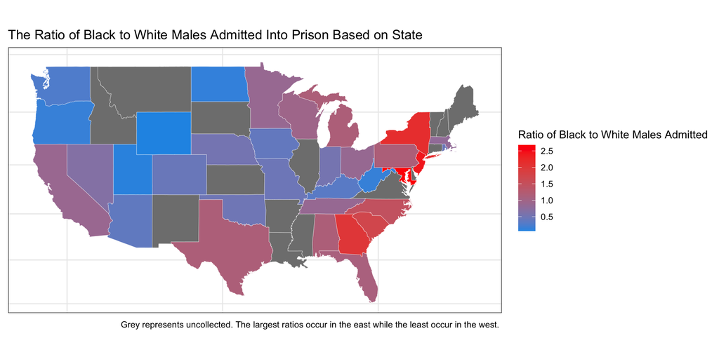

### Summary:

The following chart can be used to answer the question: *How is the difference between black and white males admitted into prison distribute geographically? Are there any patterns in the distribution of such inequality pattern?* Before analysis, it’s important to identify what and how to determine “difference.” As the focus has been the difference between race and admitted males, the use of ratio seemed to be the best fit. The use of ratio over just subtraction was preferred as ratio allowed for a more equal results. For example, a state with 100 black and 50 white admitted males have the same ratio as a state with 2 black and 1 white admitted male. Even though the states have the same ratio, if subtraction was used, the state with just more admitted people as a whole would seem like it was worse off. Now to answer the initial question, there is greater difference between black and white males admitted into prison in the east, and less in the west. This can be concluded because there are more dark red states on the right and more blue states on the left.